# R Notebook

#read in data, add library

```r
DPDA <- read.csv("Police_Arrests.csv")
DAC <- read.csv("Police_Arrest_Charges.csv")
library(tidyverse)
library(lubridate)
library(corrplot)
```

#initial view of features, categories etc.

```r
str(DAC)
```

#add features for quick date/time EDA

```r
DAC$ArMo<- format(as.Date(DAC$ArrestDate), format="%m")
DAC$ArMY<- format(as.Date(DAC$ArrestDate), format="%Y.%m")
```

#view blank and NA counts for each feature

```r
DACNA <- DAC %>% mutate_all(na_if,"")
DACNACount <- as.data.frame(map(DACNA, ~sum(is.na(.))))
```

#Look at NIBRS feature sums to better grasp relationship between features in practice

```r
NIBRSSums <- DAC %>% group_by(NIBRS_Group,
                              NIBRS_Crime_Category,
                              NIBRS_Crime,
                              NIBRS_Code,
                              NIBRS_CrimeAgainst) %>% summarize(count=n())
```

#See if warrant type might have a relationship to release type, and maybe gain insight into misc categoris

```r
WarrantSums <- DAC %>% group_by(WarrantType,
                                ReleaseType) %>% summarize(count=n())
```

#look at warrant types not A, C, or blank, keep looking to see if any patterns are there, none so far

```r
WeirdWarrantTypes <- DAC %>% filter(!WarrantType %in% c("WRNT_C", "WRNT_A", ""))
WeirdWarrantSums <- WeirdWarrantTypes %>% group_by(WarrantType, ChargeFlag, NIBRS_Code) %>% summarize(count=n())
```

#Year over year total arrests - count has been going down since 2017

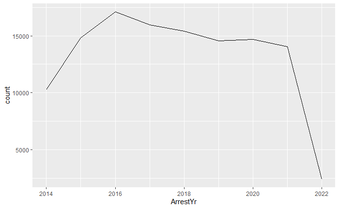

```r
AnnualChargeTotal <- DAC %>% group_by(ArrestYr) %>% summarize(count=n())
MonthlyChargeTotal <- DAC %>% group_by(ArMY, ArrestYr)  %>% summarize(count=n())
a <- ggplot(AnnualChargeTotal, aes(ArrestYr, count))
b <- ggplot(MonthlyChargeTotal, aes(ArMY, count, fill = ArrestYr))
c <- ggplot(DAC, aes(ArrestDate))
a + geom_line()
```

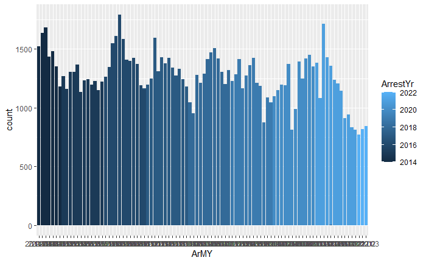

```r
b + geom_col()
```

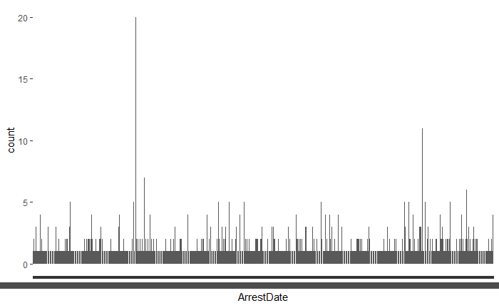

```r
c + geom_histogram(stat = "count")
```

```r
arrestbytype <- DAC %>% group_by(ArAction,
                                 NIBRS_Crime_Category, ChargeFlag) %>%
  summarize(count=n())
print(arrestbytype)
```

#Checking miscelaneous arrests for related and possible miscodes

```r
DACMisc <- filter(DAC, NIBRS_Code == "999")
```

#Filtering marijuana charges by category

```r
DACWeed <- filter(DAC, grepl("marijuana", ChargeDesc, ignore.case = TRUE))
DACWeedSP <- filter(DACWeed, grepl("poss", ChargeDesc, ignore.case = TRUE))
DACWeedSPP <- filter(DACWeed, grepl("<2oz", ChargeDesc, ignore.case = TRUE))
DACWeedNoSPP <- filter(DACWeed, !grepl("<2oz", ChargeDesc, ignore.case = TRUE))
```

#Looking at distribution of charges over time

```r
DACWeedSum <- DACWeed %>% group_by(ChargeDesc, ArMY) %>% summarize(count=n())
```

#recoding marijuana charge descriptions to reduce categories

```r
DACWeedShort <- DACWeed %>% mutate(ChargeDescShort = recode(ChargeDesc,
  "POSS MARIJUANA <2OZ" = "Small Posession",
  "POSS MARIJUANA <2OZ *DRUG FREE ZONE" = "Small Posession",
  "POSS MARIJUANA >2OZ< OR EQUAL 4OZ *DRUG FREE ZONE*" = "Medium posession",
  "POSS MARIJUANA >2OZ< OR EQUAL 4OZ" = "Medium posession",
  "POSS MARIJUANA >4OZ< OR EQUAL 5LBS" = "Large Posession",
  "POSS MARIJUANA >4OZ< OR EQUAL 5LBS *DRUG FREE ZONE*" = "Large Posession",
  "POSS MARIJUANA >50LBS< OR EQUAL 2,000LBS" = "Large Posession",
  "POSS MARIJUANA >5LBS< OR EQUAL 50LBS" = "Large Posession",
  "POSS MARIJUANA >5LBS *DRUG FREE ZONE*" = "Large Posession",
  .default = "Delivery All"))
```

```r
DACWeedShortNoSSP <- filter(DACWeedShort, ChargeDescShort != "Small Posession")
```

#Simple posession under 20z by month, year

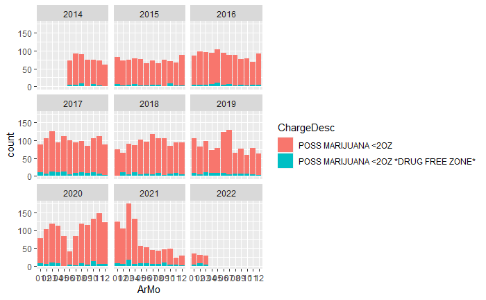

```r
d <- ggplot(DACWeedSPP, aes(ArMo, fill = ChargeDesc))
d + geom_bar() + facet_wrap(~ ArrestYr)
```

#all other posession types by month, year

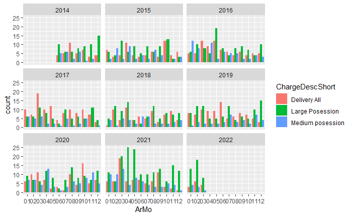

```r
e <- ggplot(DACWeedShortNoSSP, aes(ArMo, fill = ChargeDescShort))
e + geom_bar(position = "dodge") + facet_wrap(~ ArrestYr)
```

#Looking at related charges for patterns

```r
DACBSA <- filter(DAC, grepl("90", NIBRS_Code, ignore.case = TRUE))
```

```r
table(DACBSA$NIBRS_Code)
```

```r
f <- ggplot(DACBSA, aes(ArMY))
f + geom_bar(position = "dodge") + facet_wrap(~ NIBRS_Code)
```

[output not shown]

```r
DAC90D <- filter(DACBSA, NIBRS_Code == "90D")
DAC90E <- filter(DACBSA, NIBRS_Code == "90E")
DAC90Z <- filter(DACBSA, NIBRS_Code == "90Z")

Dd <- ggplot(DAC90D, aes(ArMo))
De <- ggplot(DAC90E, aes(ArMo))
Dz <- ggplot(DAC90Z, aes(ArMo))
```

```r
Dz + geom_bar(position = "dodge") + facet_wrap(~ ArrestYr)
Dd + geom_bar(position = "dodge") + facet_wrap(~ ArrestYr)
De + geom_bar(position = "dodge") + facet_wrap(~ ArrestYr)
```

[output not shown]

#inspecting all 35A offenses

```r
DACNarcRelated <- filter(DAC, UCROffense == "NARCOTICS & DRUGS")

DACNR <- DACNarcRelated %>% group_by(ChargeFlag,
                                     Severity,
                                     ChargeDesc) %>% summarize(count=n())
DACNRBlank <- filter(DACNarcRelated, ChargeDesc == "")
sum(DACNR$count)
```

# Confirm NIBRS hierarchies - Group> Crime Category > Crime, and 1:1 between Crime and Code

```r
nibrsCvsCC <- as.data.frame(table(DAC$NIBRS_Crime, DAC$NIBRS_Crime_Category))
nibrsCvsCC <- filter(nibrsCvsCC, nibrsCvsCC$Freq >0)
```

```r
nibrsCODEvsCC <- as.data.frame(table(DAC$NIBRS_Code, DAC$NIBRS_Crime_Category))
nibrsCODEvsCC <- filter(nibrsCODEvsCC, Freq >0)
```

```r
length(unique(DAC$NIBRS_Group, DAC$NIBRS_Crime_Category, DAC$NIBRS_Code, DAC$NIBRS_Crime))
length(unique(DAC$NIBRS_Crime))
```

#comparing UCS to NIBRS

```r
ucrVSnibrs <- as.data.frame(table(DAC$UCRWord, DAC$NIBRS_Crime_Category))
ucrVSnibrs2 <- filter(ucrVSnibrs, ucrVSnibrs$Freq >0)
```